# R Markdown 简介

WSJ

College of Economics，Shenzhen University

2018-09-17

# 1 基本语法

## 1.1 行内语法

- 斜体： *text*，`_text_` or `*text*`
- 黑体：**text**，`__text__` or `**text**`
- 下标：两个`~`包夹，`H~2~SO~4~` renders H<sub>2</sub>SO<sub>4</sub>
- 上标：两个`^`包夹， `R^2^` renders R<sup>2</sup>
- 显示代码：`code`和`code`显示代码块
- 行内运行R代码：`10`， 100的开根号等于 10
- 链接网站：`[text](link)`,例如 [RStudio](https://www.rstudio.com)
- 插入图片：`![image title](path/to/image)`
- 脚注：`^[]`, e.g., 这里是脚注[^1]

## 1.2 模块语法

Section headers can be written after a number of pound signs, e.g.,

```markdown
# First-level header
## Second-level header
### Third-level header
```

If you do not want a certain heading to be numbered, you can add `{-}` after the heading, e.g.,

```markdown
# Preface {-}
```

Unordered list items start with `*`, `-`, or `+`, and you can nest one list within another list by indenting the sub-list by four spaces, e.g.,

```markdown
- one item
- one item
- one item
    - one item
    - one item
```

The output is: - one item - one item - one item - one item - one item

Ordered list items start with numbers (the rule for nested lists is the same as above), e.g.,

```markdown
1. the first item
2. the second item
3. the third item
```

The output does not look too much different with the Markdown source: 1. the first item 2. the second item 3. the third item

Blockquotes are written after `>`, e.g.,

> “I thoroughly disapprove of duels. If a man should challenge me, I would take him kindly and forgivingly by the hand and lead him to a quiet place and kill him.”

> — Mark Twain

Plain code blocks can be written after three or more backticks, and you can also indent the blocks by four spaces, e.g.,

````markdown
```
This text is displayed verbatim / preformatted
```

Or indent by four spaces:

    This text is displayed verbatim / preformatted
````

# 2 数学公式

行内公式`$y=x^2$`显示$y=x^2$，整行公式（display style）用两双美元符号之间表示, `$$f(k) = {n \choose k} p^{k} (1-p)^{n-k}$$`, 结果:

$$f\left(k\right)=\binom{n}{k}p^k\left(1-p\right)^{n-k}$$

You can also use math environments inside `$ $` or `$$ $$`, e.g.,

```latex
$$\begin{array}{ccc}
x_{11} & x_{12} & x_{13}\\
x_{21} & x_{22} & x_{23}
\end{array}$$
```

$$\begin{array}{ccc}
x_{11} & x_{12} & x_{13}\\
x_{21} & x_{22} & x_{23}
\end{array}$$

```latex
$$X = \begin{bmatrix}1 & x_{1}\\
1 & x_{2}\\
1 & x_{3}
\end{bmatrix}$$
```

$$X = \begin{bmatrix}1 & x_{1}\\
1 & x_{2}\\
1 & x_{3}
\end{bmatrix}$$

```latex
$$\Theta = \begin{pmatrix}\alpha & \beta\\
\gamma & \delta
\end{pmatrix}$$
```

$$\Theta = \begin{pmatrix}\alpha & \beta\\
\gamma & \delta
\end{pmatrix}$$

```latex
$$\begin{vmatrix}a & b\\
c & d
\end{vmatrix}=ad-bc$$
```

$$\begin{vmatrix}a & b\\
c & d
\end{vmatrix}=ad-bc$$

# 3 R代码块

You can insert an R code chunk either using the RStudio toolbar (the `Insert` button) or the keyboard shortcut `Ctrl + Alt + I` (`Cmd + Option + I` on macOS).

There are a lot of things you can do in a code chunk: you can produce text output, tables, or graphics. You have fine control over all these output via chunk options, which can be provided inside the curly braces (between `` ```{r `` and `}`). For example, you can choose hide text output via the chunk option `results = 'hide'`, or set the figure height to 4 inches via `fig.height = 4`. Chunk options are separated by commas, e.g.,

````markdown
```{r, chunk-label, results='hide', fig.height=4}
````

The value of a chunk option can be an arbitrary R expression, which makes chunk options extremely flexible. For example, the chunk option `eval` controls whether to evaluate (execute) a code chunk, and you may conditionally evaluate a chunk via a variable defined previously, e.g.,

````markdown
```{r}
# execute code if the date is later than a specified day
do_it = Sys.Date() > '2018-02-14'
```

```{r, eval=do_it}
x = rnorm(100)
```
````

There are a large number of chunk options in **knitr** documented at https://yihui.name/knitr/options. We list a subset of them below:

- `eval`: Whether to evaluate a code chunk.
- `echo`: Whether to echo the source code in the output document (someone may not prefer reading your smart source code but only results).
- `results`: When set to `'hide'`, text output will be hidden; when set to `'asis'`, text output is written “as-is”, e.g., you can write out raw Markdown text from R code (like `cat('**Markdown** is cool.\n')`). By default, text output will be wrapped in verbatim elements (typically plain code blocks).
- `collapse`: Whether to merge text output and source code into a single code block in the output. This is mostly cosmetic: `collapse = TRUE` makes the output more compact, since the R source code and its text output are displayed in a single output block. The default `collapse = FALSE` means R expressions and their text output are separated into different blocks.
- `warning`, `message`, and `error`: Whether to show warnings, messages, and errors in the output document. Note that if you set `error = FALSE`, `rmarkdown::render()` will halt on error in a code chunk, and the error will be displayed in the R console. Similarly, when `warning = FALSE` or `message = FALSE`, these messages will be shown in the R console.
- `include`: Whether to include anything from a code chunk in the output document. When `include = FALSE`, this whole code chunk is excluded in the output, but note that it will still be evaluated if `eval = TRUE`. When you are trying to set `echo = FALSE`, `results = 'hide'`, `warning = FALSE`, and `message = FALSE`, chances are you simply mean a single option `include = FALSE` instead of suppressing different types of text output individually.
- `cache`: Whether to enable caching. If caching is enabled, the same code chunk will not be evaluated the next time the document is compiled (if the code chunk was not modified), which can save you time. However, I want to honestly remind you of the two hard problems in computer science (via Phil Karlton): naming things, and cache invalidation. Caching can be handy but also tricky sometimes.
- `fig.width` and `fig.height`: The (graphical device) size of R plots in inches. R plots in code chunks are first recorded via a graphical device in **knitr**, and then written out to files. You can also specify the two options together in a single chunk option `fig.dim`, e.g., `fig.dim = c(6, 4)` means `fig.width = 6` and `fig.height = 4`.
- `out.width` and `out.height`: The output size of R plots in the output document. These options may scale images. You can use percentages, e.g., `out.width = '80%'` means 80% of the page width.
- `fig.align`: The alignment of plots. It can be `'left'`, `center`, or `'right'`.
- `dev`: The graphical device to record R plots. Typically it is `'pdf'` for LaTeX output, and `'png'` for HTML output, but you can certainly use other devices, such as `'svg'` or `'jpeg'`.
- `fig.cap`: The figure caption.
- `child`: You can include a child document in the main document. This option takes a path to an external file.

# 4 图形

## 4.1 R 代码块做图

代码块选项 `fig.asp` 表示图形的高宽比。如果宽度为 6 英寸 (`fig.width = 6`) 而 `fig.asp = 0.7`, 则图形的高度为 `fig.width * fig.asp = 6 * 0.7 = 4.2`.

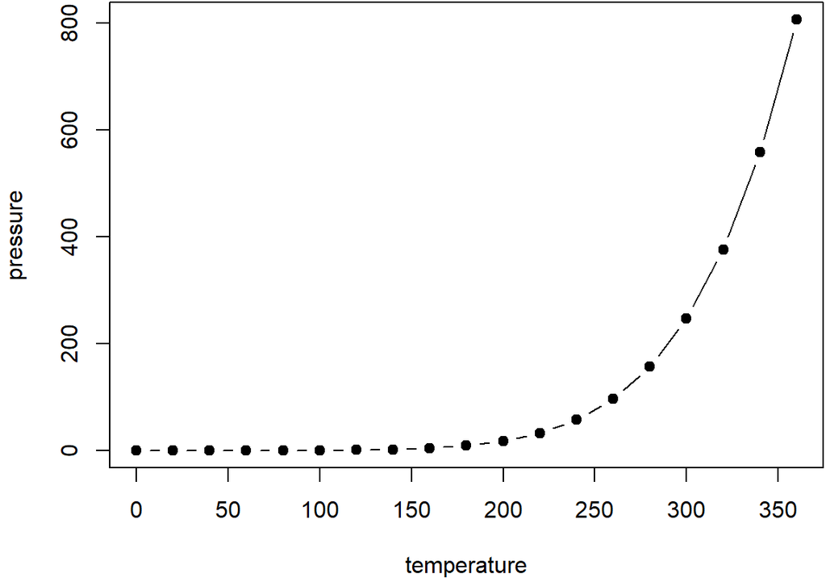

Figure 4.1: A figure example with the specified aspect ratio, width, and alignment.

```r
par(mar = c(4, 4, .1, .1))
plot(pressure, pch = 19, type = 'b')
```

`fig.width` 和 `fig.height`给出的是图形的实际大小。我们可以用 `out.width` 和 `out.height` 给出图形的输出大小。例如， `out.width = '70%'` **knitr** 会自动处理为 `.7\linewidth`，即文本宽度的70%

An example of `out.width = 70%`.

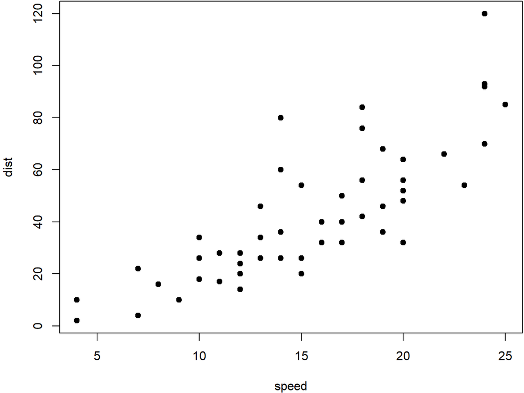

Figure 4.2: A figure example with a relative width 70%.

```r
par(mar = c(4, 4, .1, .1))
plot(cars, pch = 19)
```

如果一幅图里有多个子图，必须设 `fig.show = 'hold'`，并排图形加起来宽度不能超过文本宽度。如两个子图并排，每个不能超过`50%`。

An example of two plots, each with a width of `45%`.

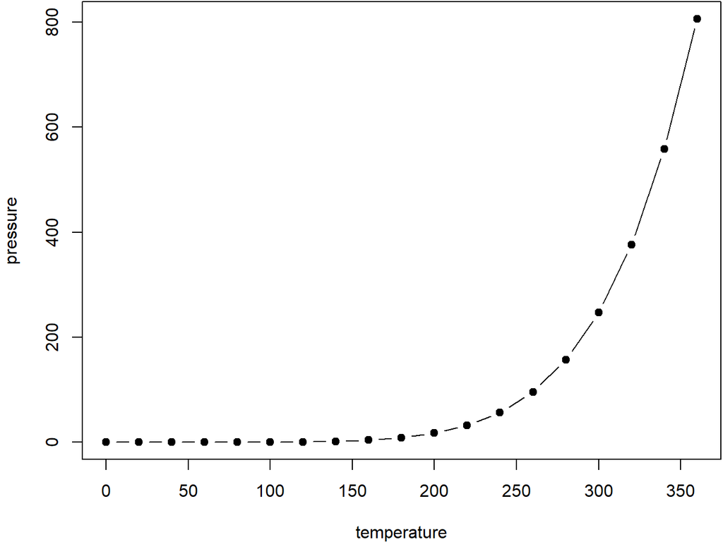

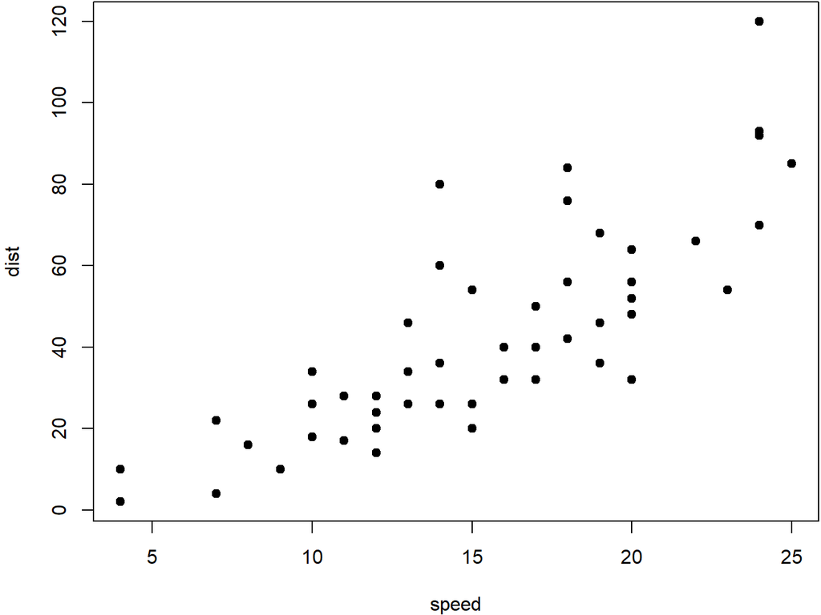

Figure 4.3: Two plots placed side by side.

```r
par(mar = c(4, 4, .1, .1))
plot(pressure, pch = 19, type = 'b')
plot(cars, pch = 19)
```

## 4.2 插入图形

R Markdown 用函数 `knitr::include_graphics()` 插入图形，要指明图形文件路径。

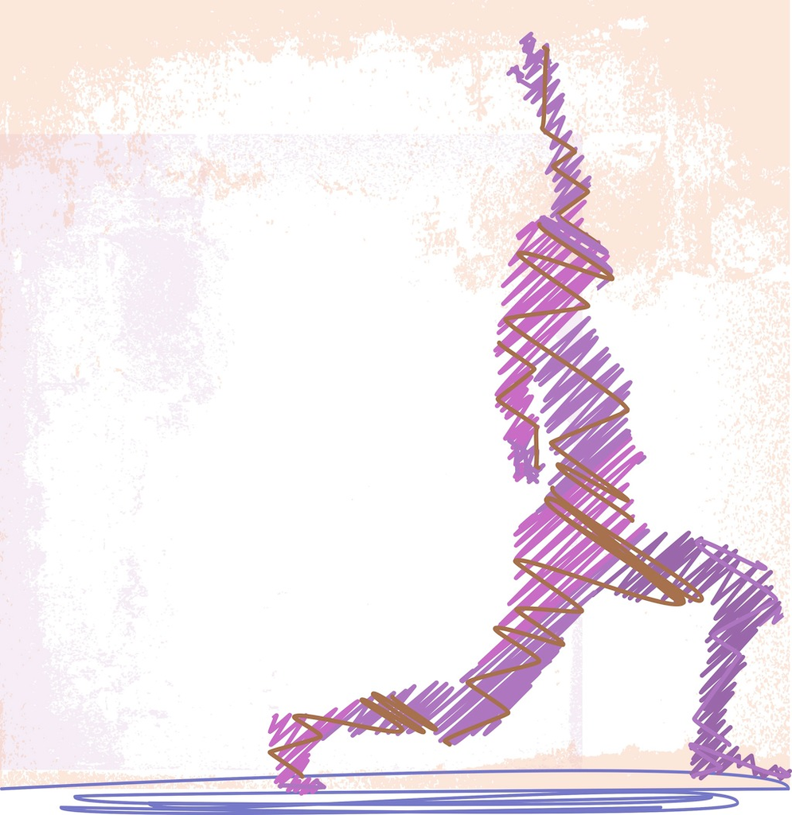

```r
knitr::include_graphics('images/run.jpg')
```

用 `include_graphics()` 插入图形有几大优点：

1. You do not need to worry about the document output format, e.g., when the output format is LaTeX, you may have to use the LaTeX command `\includegraphics{}` to include an image, and when the output format is Markdown, you have to use `![]()`. The function `include_graphics()` in **knitr** takes care of these details automatically.
2. The syntax for controlling the image attributes is the same as when images are generated from R code, e.g., chunk options `fig.cap`, `out.width`, and `fig.show` still have the same meanings.
3. `include_graphics()` can be smart enough to use PDF graphics automatically when the output format is LaTeX and the PDF graphics files exist, e.g., an image path `foo/bar.png` can be automatically replaced with `foo/bar.pdf` if the latter exists. PDF images often have better qualities than raster images in LaTeX/PDF output. To make use of this feature, set the argument `auto_pdf = TRUE`, or set the global option `options(knitr.graphics.auto_pdf = TRUE)` to enable this feature globally in an R session.
4. You can easily scale these images proportionally using the same ratio. This can be done via the `dpi` argument (dots per inch), which takes the value from the chunk option `dpi` by default. If it is a numeric value and the chunk option `out.width` is not set, the output width of an image will be its actual width (in pixels) divided by `dpi`, and the unit will be inches. For example, for an image with the size 672 x 480, its output width will be 7 inches (`7in`) when `dpi = 96`. This feature requires the package **png** and/or **jpeg** to be installed. You can always override the automatic calculation of width in inches by providing a non-NULL value to the chunk option `out.width`, or use `include_graphics(dpi = NA)`.

# 5 交叉引用

Rmarkdown没有交叉引用（cross-reference）功能，但是bookdown可以。 交叉引用包括数学公式、定理、图形、表格和章节。

用法：

- 标记： 公式`(\#eq:label)`，图形 `(\#fig:label)`，表格 `(\#tab:label)`，章节`{#label}`等。
- 引用：`\@ref(eq:label)`,`\@ref(fig:label)`,`\@ref(tab:label)`, 章节 `\@ref(label)`。

## 5.1 数学公式

要给公式编号，先要建立公式环境，然后标记 `(\#eq:label)`,例如

```latex
\begin{equation}
  f\left(k\right) = \binom{n}{k} p^k\left(1-p\right)^{n-k}
  (\#eq:binom)
\end{equation}
```

结果如下:

$$\begin{equation}
f\left(k\right)=\binom{n}{k}p^k\left(1-p\right)^{n-k} \tag{5.1}
\end{equation}$$

你可以用`\@ref(eq:binom)`引用，如，参看公式 (5.1)。

如果公式不需要自动编号，可建立 `equation*`环境：

```latex
\begin{equation*}
\frac{d}{dx}\left( \int_{a}^{x} f(u)\,du\right)=f(x)
\end{equation*}
```

$$\begin{equation*}
\frac{d}{dx}\left( \int_{a}^{x} f(u)\,du\right)=f(x)
\end{equation*}$$

公式对齐：用 `align`，`=`号左侧加上对齐标记`&`；换行用 `\\`。默认情况下，`align` 环境里每行都会指定一个编号，如果某行不要编号，可用 `\notag`。

```latex
\begin{align}
g(X_{n}) &= g(\theta)+g'({\tilde{\theta}})(X_{n}-\theta) \notag \\
\sqrt{n}[g(X_{n})-g(\theta)] &= g'\left({\tilde{\theta}}\right)
  \sqrt{n}[X_{n}-\theta ] (\#eq:align)
\end{align}
```

$$\begin{align}
g(X_{n}) &= g(\theta)+g'({\tilde{\theta}})(X_{n}-\theta) \notag \\
\sqrt{n}[g(X_{n})-g(\theta)] &= g'\left({\tilde{\theta}}\right)
\sqrt{n}[X_{n}-\theta ] \tag{5.2}
\end{align}$$

如果一个公式有多行，希望共享一个编号，可用 `split`环境：

```latex
\begin{equation}
\begin{split}
\mathrm{Var}(\hat{\beta}) & =\mathrm{Var}((X'X)^{-1}X'y)\\
 & =(X'X)^{-1}X'\mathrm{Var}(y)((X'X)^{-1}X')'\\
 & =(X'X)^{-1}X'\mathrm{Var}(y)X(X'X)^{-1}\\
 & =(X'X)^{-1}X'\sigma^{2}IX(X'X)^{-1}\\
 & =(X'X)^{-1}\sigma^{2}
\end{split}
(\#eq:var-beta)
\end{equation}
```

$$\begin{equation}
\begin{split}
\mathrm{Var}(\hat{\beta}) & =\mathrm{Var}((X'X)^{-1}X'y)\\
& =(X'X)^{-1}X'\mathrm{Var}(y)((X'X)^{-1}X')'\\
& =(X'X)^{-1}X'\mathrm{Var}(y)X(X'X)^{-1}\\
& =(X'X)^{-1}X'\sigma^{2}IX(X'X)^{-1}\\
& =(X'X)^{-1}\sigma^{2}
\end{split}
\tag{5.3}
\end{equation}$$

## 5.2 定理

用下面形式创建一个定理环境:

````markdown
```{theorem，label="yourlabel",name="theorem name"}
Here is my theorem.
```
````

一个定理的例子：

````markdown
```{theorem, pyth, name="Pythagorean theorem"}
For a right triangle, if $c$ denotes the length of the hypotenuse
and $a$ and $b$ denote the lengths of the other two sides, we have

$$a^2 + b^2 = c^2$$
```
````

结果如下：

**Theorem 5.1 (Pythagorean theorem)** For a right triangle, if $c$ denotes the length of the hypotenuse and $a$ and $b$ denote the lengths of the other two sides, we have

$$a^2 + b^2 = c^2$$

引用用法：在需要引用处插入`\@ref(thm:label)`。

参看定理 5.1。见定义5.1。

定义、推论、命题、公里、假设等类似。

注意，如果 `echo`设置为`FALSE`，定理编号失效。

**Definition 5.1** 随机变量 $X$ 的特征函数定义为
$$\varphi _{X}(t)=\operatorname {E} \left[e^{itX}\right], \; t\in\mathcal{R}$$

**Example 5.1** We derive the characteristic function of $X\sim U(0,1)$ with the probability density function $f(x)=\mathbf{1}_{x \in [0,1]}$.

$$\begin{equation*}
\begin{split}
\varphi _{X}(t) &= \operatorname {E} \left[e^{itX}\right]\\
& =\int e^{itx}f(x)dx\\
& =\int_{0}^{1}e^{itx}dx\\
& =\int_{0}^{1}\left(\cos(tx)+i\sin(tx)\right)dx\\
& =\left.\left(\frac{\sin(tx)}{t}-i\frac{\cos(tx)}{t}\right)\right|_{0}^{1}\\
& =\frac{\sin(t)}{t}-i\left(\frac{\cos(t)-1}{t}\right)\\
& =\frac{i\sin(t)}{it}+\frac{\cos(t)-1}{it}\\
& =\frac{e^{it}-1}{it}
\end{split}
\end{equation*}$$

Note that we used the fact $e^{ix}=\cos(x)+i\sin(x)$ twice.

**Lemma 5.1** For any two random variables $X_1$, $X_2$, they both have the same probability distribution if and only if

$$\varphi _{X_1}(t)=\varphi _{X_2}(t)$$

**Theorem 5.2** If $X_1$, …, $X_n$ are independent random variables, and $a_1$, …, $a_n$ are some constants, then the characteristic function of the linear combination $S_n=\sum_{i=1}^na_iX_i$ is

$$\varphi _{S_{n}}(t)=\prod_{i=1}^n\varphi _{X_i}(a_{i}t)=\varphi _{X_{1}}(a_{1}t)\cdots \varphi _{X_{n}}(a_{n}t)$$

**Proposition 5.1** The distribution of the sum of independent Poisson random variables $X_i \sim \mathrm{Pois}(\lambda_i),\: i=1,2,\cdots,n$ is $\mathrm{Pois}(\sum_{i=1}^n\lambda_i)$.

*Remark.* In some cases, it is very convenient and easy to figure out the distribution of the sum of independent random variables using characteristic functions.

**Corollary 5.1** The characteristic function of the sum of two independent random variables $X_1$ and $X_2$ is the product of characteristic functions of $X_1$ and $X_2$, i.e.,
$$\varphi _{X_1+X_2}(t)=\varphi _{X_1}(t) \varphi _{X_2}(t)$$

# 6 一个ggplot2作图的例子

`ggplot2`的几个基本概念：

- 数据（Data）和映射（Mapping）：将数据映到图像
- 几何对象（Geometric）：代表在图中看到的实际元素，如点、线、多边形等
- 统计变换（Statistics）：对数据进行某种汇总，如直方图，或将二维关系用线性模型解释
- 标度（Scale）：将数据的取值映射到图形空间，例如用：颜色、大小、形状表示不同取值
- 坐标系（Coordinate）：数据如何映射到图形所在平面，提供作图所需的坐标轴和网格线
- 分面（Facet）：将数据分解为子集，进行联合展示
- 图层（Layer）：对所需的绘图操作进行一层一层叠加，最终得到所需图形

## 6.1 散点图

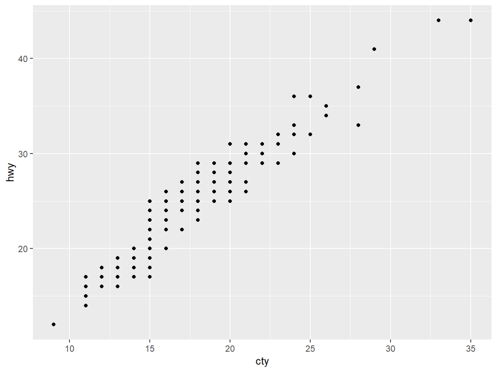

Figure 6.1: ggplot2 with points

```r
library(ggplot2)
p <- ggplot(data = mpg, mapping = aes(x = cty, y = hwy))
p + geom_point()
```

第一行指定数据集、映射（坐标轴），第二行表示在`p`的基础上加上点，`geom`表示的是 geometric object（几何对象）（见图6.1）。

mpg是ggplot2里面的一个关于汽车的数据集。

- cty：city miles per gallon
- hwy：highway miles per gallon
- year：year of manufacture
- displ：engine displacement, in litres
- cyl：number of cylinders
- class：“type” of car

## 6.2 变换颜色

按生产年份以颜色区分，`factor(year))`是把年份转化为因子形式（相当于定类变量）, 见图 6.2。

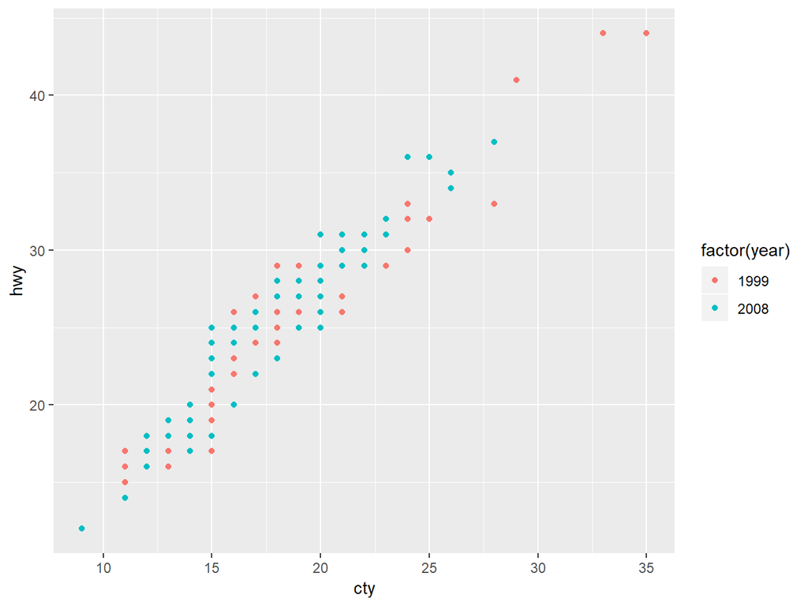

Figure 6.2: ggplot2 with points colors

```r
p <- ggplot(mpg, aes(x = cty, y = hwy, colour = factor(year)))
p + geom_point()
```

## 6.3 拟合曲线

再加一行 `+ stat_smooth()`，其中`stat`表示 statistical transformation，做了统计平滑拟合直线，以及置信区间, 见图 6.3。

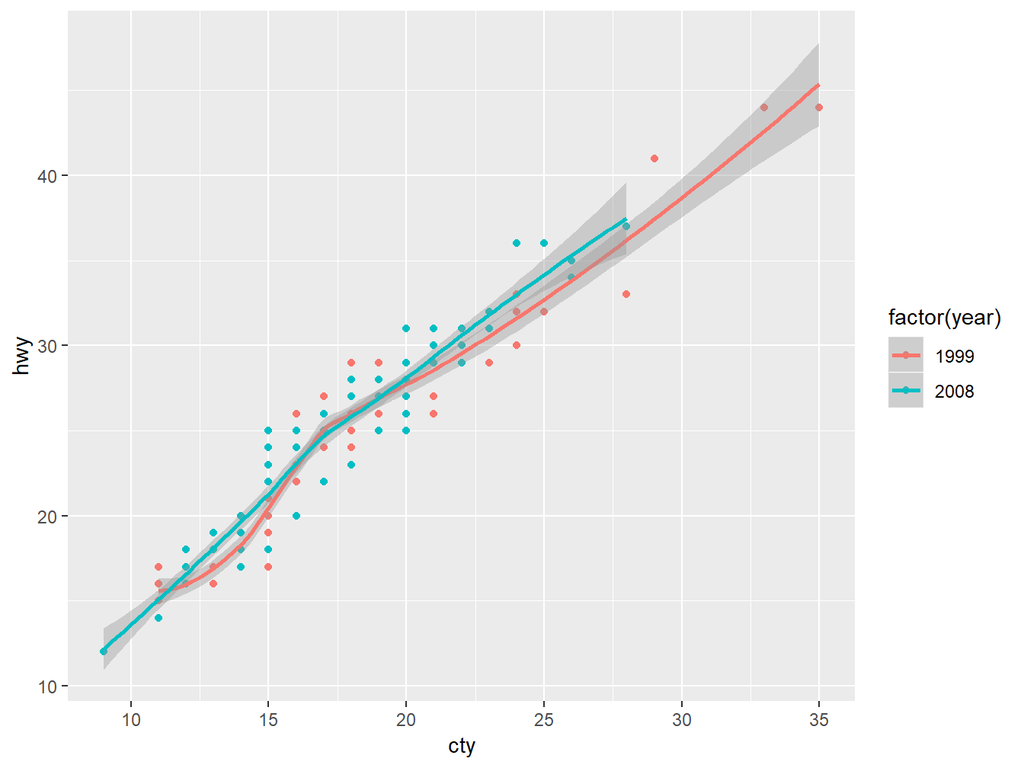

Figure 6.3: ggplot2 with smooth trends

```r
p + geom_point() + stat_smooth()
```

## 6.4 变换大小

上图的数据点明显偏小，可以让这些数据点随着**汽车排量**的大小而变化, 见图 6.4。

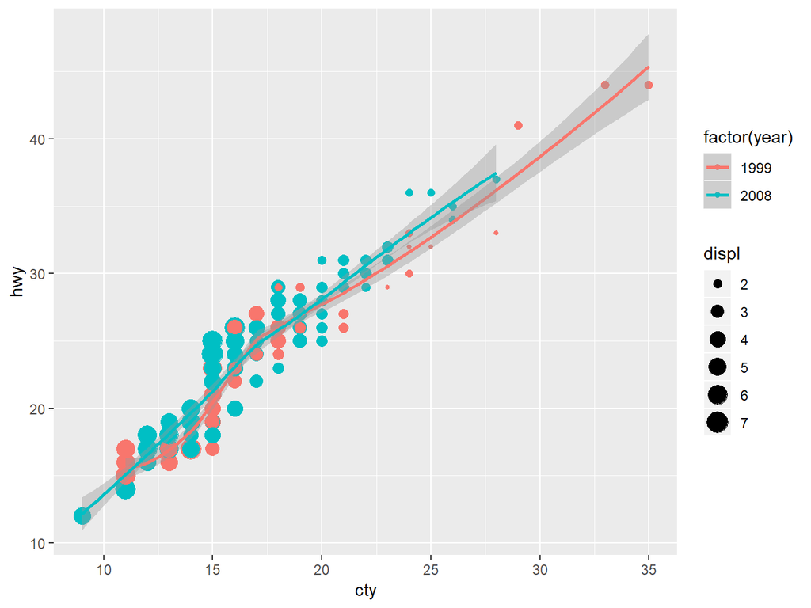

Figure 6.4: ggplot2 with variable point size

```r
p + geom_point(aes(colour = factor(year), size = displ)) +
  stat_smooth()   # 排量越大，点越大
```

## 6.5 修改透明度

数据点太密集，增加透明度，解决点与点之间的重叠的问题, 见图 6.5。

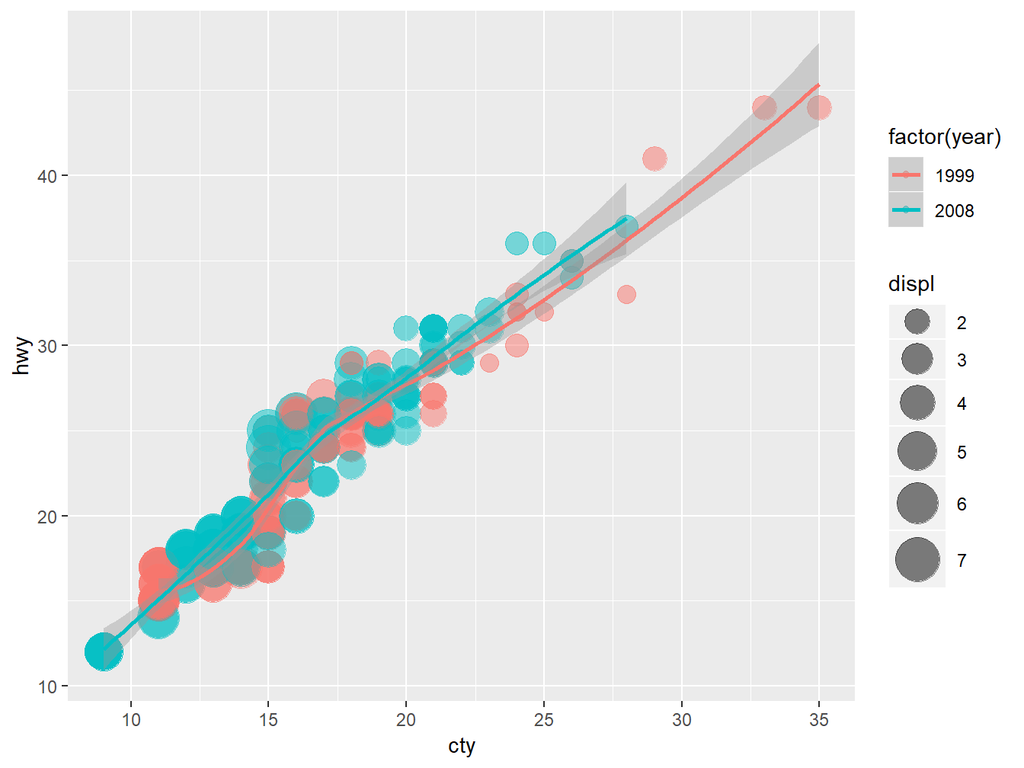

Figure 6.5: ggplot2 with transparent points

```r
p + geom_point(aes(colour = factor(year),
                   size = displ), alpha = 0.5) +
  stat_smooth() + scale_size_continuous(range = c(4, 10))
```

`alpha=0.5` 在`aes()`的外面，代表对所有的点都强制透明度为0.5。

## 6.6 图形分层

1999年与2008年数据点全部挤在一块，太拥挤了，应采用分层，见图 6.6。

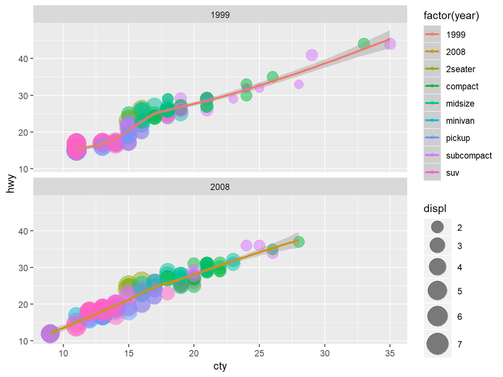

Figure 6.6: ggplot2 with facets

```r
p + geom_point(aes(colour = class, size = displ), alpha = 0.5) +
  stat_smooth() + scale_size_continuous(range = c(4, 10)) +
  facet_wrap(~ year, ncol = 1)
```

- `facet_wrap()` 是`facet`与`wrap`两个词组合，表示逐面包起来。
- `~year` 表示按变量`year`分层，将1999与2008分开。
- `ncol = 1` 代表小窗口是1列，指定了1列之后，默认就是两行（因为年份一共只有两种）。如果不加这句，会默认横着排列，或者想要指定几行，则使用`nrow = 1`。
- 这里颜色指定了 `colour = class`，代表不同种类的汽车。
- 添加了`scale_size_continuous(range = c(4, 10))`，指定`size`的变化范围。在本图中，就是控制点的绝对大小的范围， 不要太大，也不要太小。

## 6.7 添加中文标注

默认情况下图形上是不能出现中文的，要使得中文在图形中正常显示，必须在文档开头的`output`下面加上： `dev: "cairo_pdf"`。也可以在作图时加上`pdf.options(family="GB1")`。

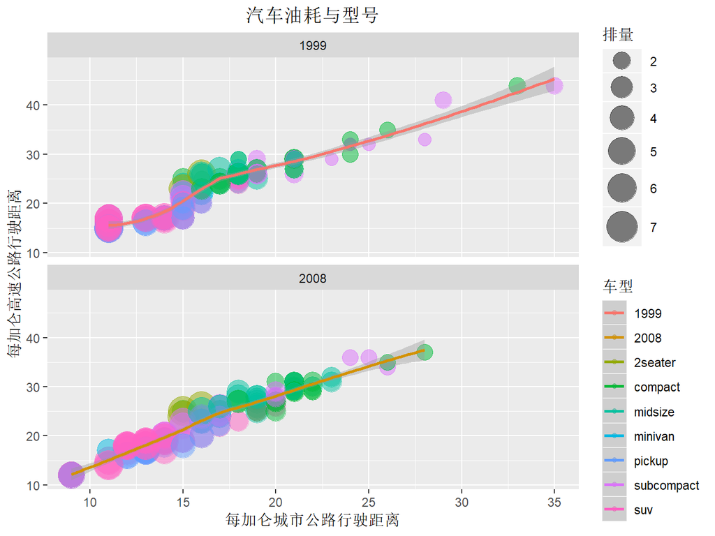

Figure 6.7: ggplot2 with Chinese characters

```r
p + geom_point(aes(colour = class, size = displ), alpha=0.5) +
  stat_smooth() + scale_size_continuous(range = c(4, 10)) +
  facet_wrap(~ year,ncol = 1) +
  labs(y = '每加仑高速公路行驶距离', x = '每加仑城市公路行驶距离',
       title = '汽车油耗与型号', size = '排量', colour = '车型') +
  theme(text = element_text(family = "STHeiti"),
        plot.title = element_text(hjust = 0.5))
```

图 6.7中，

- `labs()`修改的是标签的名称。
- `theme()`主题，更偏向于格式的修改。`text = element_text(family = "STHeiti")` 是对字体进行修改，变为黑体。Windows系统可以不添加这行，一样会显示前面labs()中设定的中文。而如果是Mac或者Linux系统，由于字体的缺失，会显示成一个一个的框框，在图像上显示不了中文字。
- `plot.title = element_text(hjust = 0.5)` 调整标题的位置，不加这行，标题会居左，加上才会居中。`hjust = 0.5` 其实就是左右移动的意思，0.5表示居中。

这个例子来自 https://blog.csdn.net/weixin_41929524/article/details/79765882。

# 7 表格

## 7.1 用R函数`kable()`制作表格

R Markdown 对数据制作表格最方便的函数是 `knitr::kable()`。

```r
knitr::kable(
  head(mtcars[, 1:8], 10), booktabs = TRUE,
  caption = 'A table of the first 10 rows of the mtcars data.'
)
```

Table 7.1: A table of the first 10 rows of the mtcars data.

|  | mpg | cyl | disp | hp | drat | wt | qsec | vs |
| --- | --- | --- | --- | --- | --- | --- | --- | --- |
| Mazda RX4 | 21.0 | 6 | 160.0 | 110 | 3.90 | 2.620 | 16.46 | 0 |
| Mazda RX4 Wag | 21.0 | 6 | 160.0 | 110 | 3.90 | 2.875 | 17.02 | 0 |
| Datsun 710 | 22.8 | 4 | 108.0 | 93 | 3.85 | 2.320 | 18.61 | 1 |
| Hornet 4 Drive | 21.4 | 6 | 258.0 | 110 | 3.08 | 3.215 | 19.44 | 1 |
| Hornet Sportabout | 18.7 | 8 | 360.0 | 175 | 3.15 | 3.440 | 17.02 | 0 |
| Valiant | 18.1 | 6 | 225.0 | 105 | 2.76 | 3.460 | 20.22 | 1 |
| Duster 360 | 14.3 | 8 | 360.0 | 245 | 3.21 | 3.570 | 15.84 | 0 |
| Merc 240D | 24.4 | 4 | 146.7 | 62 | 3.69 | 3.190 | 20.00 | 1 |
| Merc 230 | 22.8 | 4 | 140.8 | 95 | 3.92 | 3.150 | 22.90 | 1 |
| Merc 280 | 19.2 | 6 | 167.6 | 123 | 3.92 | 3.440 | 18.30 | 1 |

If you want to put multiple tables in a single table environment, wrap the data objects (usually data frames in R) into a list. Please note that this feature is only available in HTML and PDF output.

```r
knitr::kable(
  list(
    head(iris[, 1:2], 3),
    head(mtcars[, 1:3], 5)
  ),
  caption = 'A Tale of Two Tables.', booktabs = TRUE
)
```

Table 7.2: A Tale of Two Tables.

| Sepal.Length | Sepal.Width |
| --- | --- |
| 5.1 | 3.5 |
| 4.9 | 3.0 |
| 4.7 | 3.2 |

|  | mpg | cyl | disp |
| --- | --- | --- | --- |
| Mazda RX4 | 21.0 | 6 | 160 |
| Mazda RX4 Wag | 21.0 | 6 | 160 |
| Datsun 710 | 22.8 | 4 | 108 |
| Hornet 4 Drive | 21.4 | 6 | 258 |
| Hornet Sportabout | 18.7 | 8 | 360 |

```r
knitr::kable(
  iris[1:5, ], longtable = TRUE, booktabs = TRUE,
  caption = 'A table generated by the longtable package.'
)
```

Table 7.3: A table generated by the longtable package.

| Sepal.Length | Sepal.Width | Petal.Length | Petal.Width | Species |
| --- | --- | --- | --- | --- |
| 5.1 | 3.5 | 1.4 | 0.2 | setosa |
| 4.9 | 3.0 | 1.4 | 0.2 | setosa |
| 4.7 | 3.2 | 1.3 | 0.2 | setosa |
| 4.6 | 3.1 | 1.5 | 0.2 | setosa |
| 5.0 | 3.6 | 1.4 | 0.2 | setosa |

## 7.2 制作Markdown表格

用Markdown制作表格很简单，直接用`---` 和 `|`分隔即可。

Pandoc supports several types of [Markdown tables,](http://pandoc.org/MANUAL.html#tables) such as simple tables, multiline tables, grid tables, and pipe tables. What `knitr::kable()` generates is a simple table like this:

```markdown
Table: A simple table in Markdown.

 First Header | Second Header
------------- | -------------
Content Cell  | Content Cell
Content Cell  | Content Cell
```

A simple table in Markdown.

[output not shown]

You can use any types of Markdown tables in your document.

# 8 文献引用

学术论文一般做法是，把所有文献以 **BibTeX** 格式保存为一个`.bib`文件，然后在论文中随时插入引用。

**引用**：如果是作者-年格式，`@R-rmarkdown` 表示作者姓名（年份），而 `[@R-rmarkdown]` 则表示（作者 年份）。

如果是编号格式，则`@R-rmarkdown`表示序号，而 `[@R-rmarkdown]` 则表示序号为上标。

示例 Allaire et al. (2018)；示例(Allaire et al. 2018)。

如何产生Bibtex文献格式？

- 一般用文献管理软件（如Zotero、Endnote等）把参考文献转为`.bib`文件。
- 可以在知网、谷歌学术、百度学术等网站查找文献，产生Bibtex引用格式。
- 一些常用软件包夜可以用**knitr** 的函数 `write_bib()`产生。

Although Pandoc supports multiple ways of writing citations, we recommend you to use **BibTeX** databases because they work best with LaTeX/PDF output. Pandoc can process other types of bibliography databases with the utility `pandoc-citeproc` (https://github.com/jgm/pandoc-citeproc), but it may not render certain bibliography items correctly (especially in case of multiple authors per item), and BibTeX can do a better job when the output format is LaTeX. With BibTeX databases, you will be able to define the bibliography style if it is required by a certain publisher or journal.

A BibTeX database is a plain-text file (with the conventional filename extension `.bib`) that consists of bibliography entries like this:

```
@Manual{R-base,
  title = {R: A Language and Environment for Statistical
    Computing},
  author = {{R Core Team}},
  organization = {R Foundation for Statistical Computing},
  address = {Vienna, Austria},
  year = {2016},
  url = {https://www.R-project.org/},
}
```

A bibliography entry starts with `@type{`, where `type` may be `article`, `book`, `manual`, and so on.[^2] Then there is a citation key, like `R-base` in the above example. To cite an entry, use `@key` or `[@key]` (the latter puts the citation in braces), e.g., `@R-base` is rendered as R Core Team (2018), and `[@R-base]` generates “(R Core Team 2018)”. If you are familiar with the **natbib** package in LaTeX, `@key` is basically `\citet{key}`, and `[@key]` is equivalent to `\citep{key}`.

There are a number of fields in a bibliography entry, such as `title`, `author`, and `year`, etc. You may see https://en.wikipedia.org/wiki/BibTeX for possible types of entries and fields in BibTeX.

There is a helper function `write_bib()` in **knitr** to generate BibTeX entries automatically for R packages. Note that it only generates one BibTeX entry for the package itself at the moment, whereas a package may contain multiple entries in the `CITATION` file, and some entries are about the publications related to the package. These entries are ignored by `write_bib()`.

```r
# the second argument can be a .bib file
knitr::write_bib(c('knitr','bookdown'), '', width = 60)
```

```
@Manual{R-bookdown,
  title = {bookdown: Authoring Books and Technical Documents
    with R Markdown},
  author = {Yihui Xie},
  year = {2018},
  note = {R package version 0.7},
  url = {https://CRAN.R-project.org/package=bookdown},
}
@Manual{R-knitr,
  title = {knitr: A General-Purpose Package for Dynamic Report
    Generation in R},
  author = {Yihui Xie},
  year = {2018},
  note = {R package version 1.20},
  url = {https://CRAN.R-project.org/package=knitr},
}
```

Once you have one or multiple `.bib` files, you may use the field `bibliography` in the YAML metadata of your first R Markdown document (which is typically `index.Rmd`), and you can also specify the bibliography style via `biblio-style` (this only applies to PDF output), e.g.,

```yaml
---
bibliography: ["one.bib", "another.bib", "yet-another.bib"]
biblio-style: "apalike"
link-citations: true
---
```

The field `link-citations` can be used to add internal links from the citation text of the author-year style to the bibliography entry in the HTML output.

When the output format is LaTeX, citations will be automatically put in a chapter or section. For non-LaTeX output, you can add an empty chapter as the last chapter of your book. For example, if your last chapter is the Rmd file `06-references.Rmd`, its content can be an inline R expression:

```markdown
`r if (knitr::is_html_output()) '# References {-}'`
```

为了试试中文的引用，我通过Zotero产生一个bibtex文献（注意中文引用显示为–，需要自行修改）(柯忠义 2017)。

# 参考文献

Allaire, JJ, Yihui Xie, Jonathan McPherson, Javier Luraschi, Kevin Ushey, Aron Atkins, Hadley Wickham, Joe Cheng, and Winston Chang. 2018. *Rmarkdown: Dynamic Documents for R*. https://CRAN.R-project.org/package=rmarkdown.

R Core Team. 2018. *R: A Language and Environment for Statistical Computing*. Vienna, Austria: R Foundation for Statistical Computing. https://www.R-project.org/.

柯忠义. 2017. “创业板上市公司经济绩效及影响因素——基于贝叶斯模型平均法 (BMA) 的实证研究.” *数量经济技术经济研究* 34 (1): 146–60.

[^1]: This is a footnote.
[^2]: The type name is case-insensitive, so it does not matter if it is `manual`, `Manual`, or `MANUAL`.